# Prediction Assignment Writeup

The website http://groupware.les.inf.puc-rio.br/har provided lot of information regarding weight lifting exercise data colected by the devices like Fitbit, Jawbone and Nike FuelBand. In this project, the goal will be to use data from accelerometers on the belt, forearm, arm, and dumbell of 6 participants to predict the manner in which praticipants did the exercise.The dependent variable is classe and we can use any predictors that are available in the data. The data sets pml-training.csv and pml-testing.csv are available from the web site.

```r
options(warn=-1)
library(caret)
library(randomForest)
library(Hmisc)
set.seed(1024)
training_data <- read.csv("/Users/502573958/Downloads/pml-training.csv",na.strings=c("", "NA", "NULL") )
evaluation_data <- read.csv("/Users/502573958/Downloads/pml-testing.csv", na.strings=c("", "NA", "NULL") )
```

## Data Processing:

This data consists of so many NA’s and unrelaed features. Can simply omit all of them and create a new training_corrected data for prediction purposes.Also remove the unrelaed features like username, window etc.

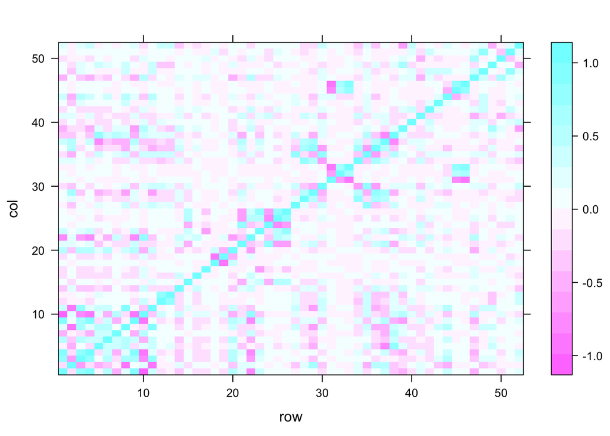

```r
training_cor <- training_data[ , colSums(is.na(training_data)) == 0]
undesirable_features = c('X', 'user_name', 'raw_timestamp_part_1', 'raw_timestamp_part_2', 'cvtd_timestamp', 'new_window', 'num_window')
training_corrected <- training_cor[, -which(names(training_cor) %in% undesirable_features)]
corrMatrix <- cor(na.omit(training_corrected[sapply(training_corrected, is.numeric)]))
corrDF <- expand.grid(row = 1:52, col = 1:52)
corrDF$correlation <- as.vector(corrMatrix)
levelplot(correlation ~ row+ col, corrDF)
```

## Tidy data: Also Remove the correlated varaibles beyond 0.9 so that we can use only independent variables. Then obtained data of 19622 with 46 features instead of 160

```r
removecor = findCorrelation(corrMatrix, cutoff = .90, verbose = TRUE)
```

```
## Compare row 10  and column  1 with corr  0.992
##   Means:  0.27 vs 0.168 so flagging column 10
## Compare row 1  and column  9 with corr  0.925
##   Means:  0.25 vs 0.164 so flagging column 1
## Compare row 9  and column  4 with corr  0.928
##   Means:  0.233 vs 0.161 so flagging column 9
## Compare row 8  and column  2 with corr  0.966
##   Means:  0.245 vs 0.157 so flagging column 8
## Compare row 19  and column  18 with corr  0.918
##   Means:  0.091 vs 0.158 so flagging column 18
## Compare row 46  and column  31 with corr  0.914
##   Means:  0.101 vs 0.161 so flagging column 31
## Compare row 46  and column  33 with corr  0.933
##   Means:  0.083 vs 0.164 so flagging column 33
## All correlations <= 0.9
```

```r
training_corrected = training_corrected[,-removecor]
inTrain <- createDataPartition(y=training_corrected$classe, p=0.7, list=FALSE)
training <- training_corrected[inTrain,]
testing <- training_corrected[-inTrain,]
```

## Prediction Models:

After obtaining the tidy data, it can be used for Prediction. For prediction, I used three different models like tree, rpart and Random Forests. Plot the Tree.

```r
library(tree)
set.seed(12345)
tree.training <- tree(classe~., data=training)
summary(tree.training)
```

```
##
## Classification tree:
## tree(formula = classe ~ ., data = training)
## Variables actually used in tree construction:
##  [1] "pitch_forearm"     "magnet_belt_y"     "accel_forearm_z"
##  [4] "magnet_dumbbell_y" "roll_forearm"      "magnet_dumbbell_z"
##  [7] "accel_dumbbell_y"  "pitch_belt"        "yaw_belt"
## [10] "accel_forearm_x"   "yaw_dumbbell"      "magnet_forearm_y"
## [13] "magnet_arm_x"      "accel_dumbbell_z"  "gyros_belt_z"
## Number of terminal nodes:  21
## Residual mean deviance:  1.638 = 22470 / 13720
## Misclassification error rate: 0.3181 = 4370 / 13737
```

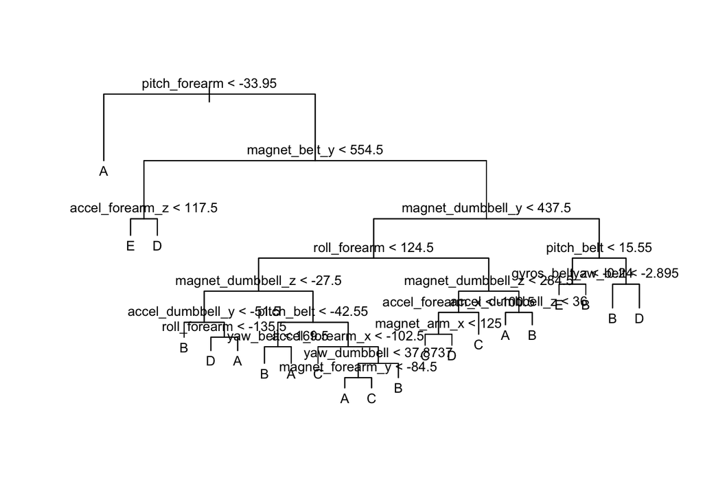

```r
plot(tree.training)
text(tree.training,pretty=0, cex =.8)
```

Prediction using rpart (49%)

```r
library(caret)
modFit <- train(classe ~ .,method="rpart",data=training)
print(modFit$finalModel)
```

```
## n= 13737
##
## node), split, n, loss, yval, (yprob)
##       * denotes terminal node
##
##  1) root 13737 9831 A (0.28 0.19 0.17 0.16 0.18)
##    2) pitch_forearm< -33.95 1089    5 A (1 0.0046 0 0 0) *
##    3) pitch_forearm>=-33.95 12648 9826 A (0.22 0.21 0.19 0.18 0.2)
##      6) magnet_belt_y>=554.5 11641 8820 A (0.24 0.23 0.21 0.18 0.15)
##       12) magnet_dumbbell_y< 437.5 9701 6939 A (0.28 0.18 0.24 0.17 0.13)
##         24) roll_forearm< 121.5 6021 3565 A (0.41 0.18 0.18 0.14 0.094) *
##         25) roll_forearm>=121.5 3680 2437 C (0.083 0.18 0.34 0.22 0.18)
##           50) accel_forearm_x>=-108.5 2624 1625 C (0.091 0.22 0.38 0.091 0.22) *
##           51) accel_forearm_x< -108.5 1056  497 D (0.063 0.083 0.23 0.53 0.093) *
##       13) magnet_dumbbell_y>=437.5 1940 1026 B (0.03 0.47 0.039 0.22 0.24) *
##      7) magnet_belt_y< 554.5 1007  175 E (0.00099 0.003 0 0.17 0.83) *
```

```r
tree.pred=predict(modFit, testing)
predMatrix = with(testing,table(tree.pred,classe))
sum(diag(predMatrix))/sum(as.vector(predMatrix)) # error rate 49% and 31%
```

```
## [1] 0.4907392
```

Prediction using tree process (Accuracy 67%)

```r
tree.pred=predict(tree.training,testing,type="class")
predMatrix = with(testing,table(tree.pred,classe))
sum(diag(predMatrix))/sum(as.vector(predMatrix)) # 67% Pred error rate 31%
```

```
## [1] 0.6735769
```

## Cross Validations:

Prediction for tree using Cross Validation Pruning and further pruning. Plot the training data

```r
cv.training=cv.tree(tree.training,FUN=prune.misclass)
cv.training
```

```
## $size
##  [1] 21 20 19 16 15 14 13 10  7  5  1
##
## $dev
##  [1] 4540 4611 5069 5157 5175 5274 5419 6499 6709 7217 9831
##
## $k
##  [1]     -Inf  72.0000 122.0000 129.6667 132.0000 148.0000 172.0000
##  [8] 204.0000 224.0000 257.5000 656.7500
##
## $method
## [1] "misclass"
##
## attr(,"class")
## [1] "prune"         "tree.sequence"
```

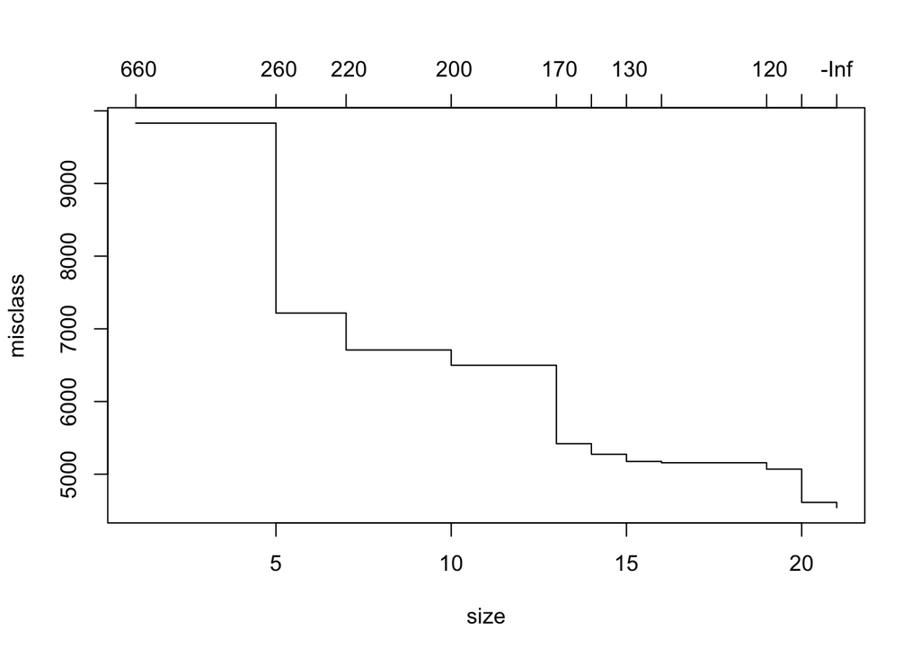

```r
plot(cv.training)
```

```r
prune.training <- prune.misclass(tree.training, best=18)
tree.pred=predict(prune.training,testing,type="class")
predMatrix = with(testing,table(tree.pred,classe))
sum(diag(predMatrix))/sum(as.vector(predMatrix))
```

```
## [1] 0.6589635
```

## Random Forest Prediction:

```r
require(randomForest)
set.seed(12345)
rf.training <- randomForest(classe~., data=training, ntree=100, importance=TRUE)
rf.training
```

```
##
## Call:
##  randomForest(formula = classe ~ ., data = training, ntree = 100,      importance = TRUE)
##                Type of random forest: classification
##                      Number of trees: 100
## No. of variables tried at each split: 6
##
##         OOB estimate of  error rate: 0.73%
## Confusion matrix:
##      A    B    C    D    E  class.error
## A 3904    1    0    0    1 0.0005120328
## B   19 2629    9    0    1 0.0109104590
## C    0   23 2365    8    0 0.0129382304
## D    1    0   25 2224    2 0.0124333925
## E    0    0    3    7 2515 0.0039603960
```

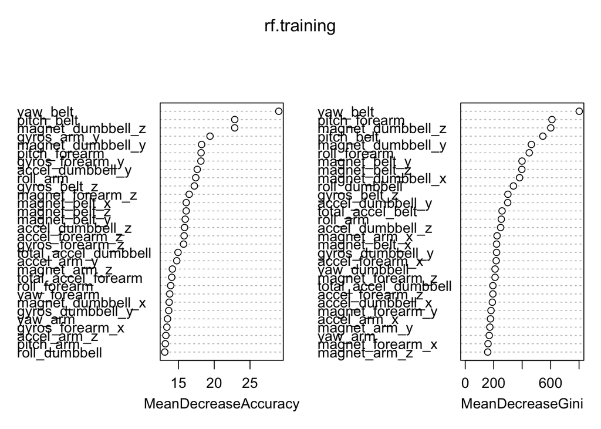

```r
##Plot the RF Training data
varImpPlot(rf.training)
```

```r
tree.pred <- predict(rf.training, testing, type="class")
predMatrix <- with(testing, table(tree.pred, classe))
sum(diag(predMatrix))/sum(as.vector(predMatrix))  ## gave 99.35% accuracy
```

```
## [1] 0.9925234
```

## Conclusion:

For evaluation, the test data was provided in the web site. evaluation_data is used to classify the levels successfuly. All 20 test cases are correctly classified using the random forest model.

```r
answers <- predict(rf.training, evaluation_data)
answers
```

```
##  1  2  3  4  5  6  7  8  9 10 11 12 13 14 15 16 17 18 19 20
##  B  A  B  A  A  E  D  B  A  A  B  C  B  A  E  E  A  B  B  B
## Levels: A B C D E
```